# Um estudo: Frota de veículos no Brasil

Ricardo Filho

Os dados foram coletados do site do [Denatran](http://infraestrutura.gov.br/relatorios-estatisticos/115-portal-denatran/9484-frota-de-ve%C3%ADculos-2020.html) (Departamento Nacional de Trânsito), que os publicou em janeiro de 2020, com atualizações no final de março do mesmo ano.

Os dados foram tratados e salvos num banco de dados MySQL, e para esta análise apenas exportados para o arquivo csv.

Os dados das cidades foram retirados do repositório chandez/Estados-Cidades-IBGE também salvos num banco de dados, tratados e exportados para um arquivo csv.

Os dados da população foram retirados do site do IBGE [Estimativas da População](https://www.ibge.gov.br/estatisticas/sociais/populacao/9103-estimativas-de-populacao.html?=&t=downloads).

### Preparação

```r
getwd()
setwd('C:/xampp/htdocs/repos/ds/analises/frota_veiculos')

# Bibliotecas do projeto
library(ggplot2)
library(dplyr)
library(Hmisc)
library(stringr)
library(knitr)
library(scales)
library(sqldf)
library(shiny)
library(ggthemes)
library(RColorBrewer)
library(highcharter)
library(viridis)
```

### Carregar dados

```r
df_frotas <- read.csv('data/denatran_frotas.csv', sep=';')
df_cidades <- read.csv('data/cidades.csv', sep=';')
df_populacao <- read.csv('data/populacao.csv', sep=';')
```

Ver as primeiras linhas do dataset.

A fonte de dados do Denatran, traz além das quantidades de veículos por cidades e estados, também divide os veículos por seu tipo, desde carros, motos, caminhões, ônibus até bonde e tratores, e esses tipos são definidos pela CTB (Código de Trânsito Brasileiro).

```r
# str(df_frotas)
# summary(df_frotas)
dim(df_frotas)
```

```
## [1] 5570   29
```

O dataset possui 5570 linhas e 29 colunas. Cada linha corresponde a uma cidade, e temos nas colunas adjacentes as informações do nome, estado e região destas cidades (e seus ids). As colunas seguintes possuem os tipos de veículos e suas quantidades, no final temos uma coluna de total de veículos por cidade.

```r
head(df_frotas, n = 5)
```

|  | id_cidade | nome_cidade | id_estado | uf | nome_estado | id_regiao | nome_regiao | automovel | bonde | caminhao | caminhao_trator | caminhonete | camioneta | chassi_plataforma | ciclomotor | micro_onibus | motocicleta | motoneta | onibus | quadriciclo | reboque | semirreboque | side_car | outros | trator_de_esteiras | trator_de_rodas | triciclo | utilitario | total_frota |
| --- | --- | --- | --- | --- | --- | --- | --- | --- | --- | --- | --- | --- | --- | --- | --- | --- | --- | --- | --- | --- | --- | --- | --- | --- | --- | --- | --- | --- | --- |
| 1 | 79 | Acrelândia | 1 | AC | Acre | 1 | Norte | 1347 | 0 | 344 | 27 | 642 | 49 | 0 | 2 | 10 | 3210 | 374 | 42 | 0 | 67 | 39 | 0 | 0 | 0 | 0 | 0 | 10 | 6163 |
| 2 | 80 | Assis Brasil | 1 | AC | Acre | 1 | Norte | 319 | 0 | 25 | 0 | 146 | 18 | 0 | 2 | 3 | 1118 | 123 | 3 | 0 | 15 | 0 | 0 | 0 | 0 | 0 | 0 | 2 | 1774 |
| 3 | 81 | Brasiléia | 1 | AC | Acre | 1 | Norte | 2287 | 0 | 279 | 154 | 1165 | 80 | 0 | 4 | 6 | 4435 | 960 | 19 | 0 | 112 | 203 | 0 | 0 | 0 | 0 | 2 | 31 | 9737 |
| 4 | 82 | Bujari | 1 | AC | Acre | 1 | Norte | 615 | 0 | 121 | 30 | 269 | 15 | 0 | 7 | 5 | 938 | 51 | 13 | 0 | 23 | 38 | 0 | 0 | 0 | 0 | 1 | 3 | 2129 |
| 5 | 83 | Capixaba | 1 | AC | Acre | 1 | Norte | 607 | 0 | 88 | 3 | 227 | 30 | 0 | 5 | 3 | 1054 | 123 | 17 | 0 | 22 | 4 | 0 | 0 | 0 | 0 | 0 | 1 | 2184 |

### Análise

A análise aqui será fluída, tentando partir do mais geral mergulhando nas especificidades.

**1. Qual a frota total de veículos do Brasil?**

```r
sum(df_frotas$total_frota) -> frota_total
print(paste("Frota total é de ", format(frota_total, big.mark = "."), " veículos"))
```

```
## [1] "Frota total é de  105.376.352  veículos"
```

**2. Vamos colocar numa tabela, a quantidade total de veículos por seu tipo, ordenando do maior para o menor.**

Não temos uma linha com os totais para cada tipo de veículo. Poderíamos criar uma variável para cada tipo, mas isso daria muito trabalho, porque das 29 colunas, 21 são os tipos dos veículos. Mas, podemos criar um novo dataframe com duas informações: o tipo do veículo e o seu total.

```r
# Criar um novo dataframe a partir do original, com uma coluna sendo os nomes dos tipos e outra com os totais
df_tipos_frota <- data.frame(tipo_frota = names(df_frotas[,8:28]), total = colSums(df_frotas[,8:28]))

# Ordenar os registros
df_tipos_frota <- df_tipos_frota %>% arrange(desc(total))

# reiniciar o índice das colunas
rownames(df_tipos_frota) <- NULL

# Melhorando a visualização do nome: retirar os underline e capitalizar a primeira letra
df_tipos_frota$tipo_frota <- str_replace(df_tipos_frota$tipo_frota, '_', ' ')
df_tipos_frota$tipo_frota <- str_replace(df_tipos_frota$tipo_frota, '_', ' ') # ???
df_tipos_frota$tipo_frota <- capitalize(df_tipos_frota$tipo_frota)

# df_tipos_frota
```

Podemos melhorar esse dataframe, e adicionar uma coluna com as porcentagens em relação ao total.

```r
df_tipos_frota$quantidade_rel <- round((df_tipos_frota$total / frota_total) * 100,4)

# mostrar tabela do knitr
kable(df_tipos_frota, caption="Total por tipo de veículo")
```

Total por tipo de veículo

| tipo_frota | total | quantidade_rel |
| --- | --- | --- |
| Automovel | 56927307 | 54.0228 |
| Motocicleta | 23295373 | 22.1068 |
| Caminhonete | 8023970 | 7.6146 |
| Motoneta | 4611464 | 4.3762 |
| Camioneta | 3623060 | 3.4382 |
| Caminhao | 2834488 | 2.6899 |
| Reboque | 1740740 | 1.6519 |
| Semirreboque | 1024352 | 0.9721 |
| Utilitario | 1022862 | 0.9707 |
| Caminhao trator | 703661 | 0.6678 |
| Onibus | 650075 | 0.6169 |
| Micro onibus | 414384 | 0.3932 |
| Ciclomotor | 406411 | 0.3857 |
| Triciclo | 37152 | 0.0353 |
| Trator de rodas | 33095 | 0.0314 |
| Outros | 17207 | 0.0163 |
| Side car | 8527 | 0.0081 |
| Chassi plataforma | 1716 | 0.0016 |
| Quadriciclo | 255 | 0.0002 |
| Trator de esteiras | 211 | 0.0002 |
| Bonde | 42 | 0.0000 |

Aqui podemos ver que os automóveis representam mais da metade do total de veículos, com um pouco mais do dobro do segundo colocado, as motocicletas. Inclusive, ambos os tipos dominam o mercado nacional, com praticamente 3/4 de toda a frota. Vemos que apenas os 9 primeiros veículos passam da casa de 1 milhão de unidades.

**3. Plotar um gráfico de barras dos veículos com quantidades acima de 1 milhão de unidades.**

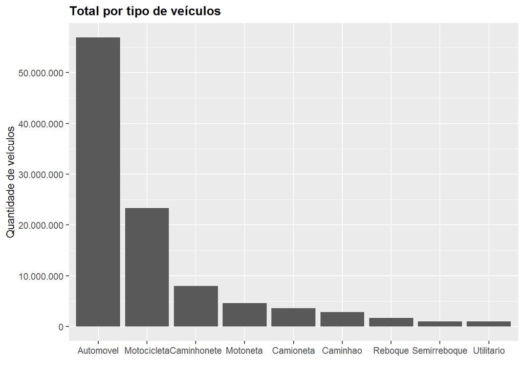

```r
df_tipos_frota_1m <- df_tipos_frota[df_tipos_frota$total > 1000000, 1:2]

# Formatar o valor da escala de y
point <- format_format(big.mark = ".", decimal.mark = ",", scientific = FALSE)

max_tipo_frota <- max(df_tipos_frota_1m$total)

ggplot(df_tipos_frota_1m, aes(x= reorder(tipo_frota, -total), y=total)) +
  geom_bar(stat = "identity") +
  ggtitle('Total por tipo de veículos') +
  xlab('') +
  ylab('Quantidade de veículos') +
  scale_y_continuous(labels = point, limits = c(0,max_tipo_frota), breaks = seq(0, max_tipo_frota, by=10000000)) +
  theme(legend.position="none",
        plot.title = element_text(size = 12, face='bold'),
        axis.title = element_text(size=10, color='black'))
```

Podemos imaginar que destes vários tipos de veículos, nem todos eles são usados para circulação de pessoas e mercadorias, alguns têm objetivos bem definidos. Por exemplo, um caminhão trator não é bem o tipo de veículo que as pessoas usem para circulação, podemos até vê-los rodando por aí, mas normalmente ele é usado em obras ou para serviços específicos, como fazer e/ou tampar buracos. O mesmo vale para reboques, semirreboques e outros tipos de tratores.

Então, daquele número total de veículos, vamos separar parte dele, considerando agora os tipos de veículos que são mais usados para circulação de pessoas e mercadorias: Automóvel, caminhão, caminhonete, camioneta, ciclomotor, micro-ônibus, motocicleta, motoneta, ônibus, quadriciclo, triciclo e utilitário.

- grupo carros = Automóvel, caminhonete, camioneta, utilitário
- grupo motos = Ciclomotor, motocicleta, motoneta, quadriciclo, triciclo
- grupo caminhões = Caminhão
- grupo ônibus = Micro-ônibus, ônibus
- grupo outros = veículos-ferramenta, bonde, e outros

```r
# Criando os grupos

gr1 <- c("Automovel", "Caminhonete", "Camioneta", "Utilitario")
gr2 <- c("Motocicleta", "Motoneta", "Ciclomotor", "Triciclo", "Quadriciclo")
gr3 <- c("Caminhao")
gr4 <- c("Micro onibus", "Onibus")
# gr5 = outros

df_tipos_frota$grupo <- ifelse(df_tipos_frota$tipo_frota %in% gr1, "Carros",
                        ifelse(df_tipos_frota$tipo_frota %in% gr2, "Motos",
                        ifelse(df_tipos_frota$tipo_frota %in% gr3, "Caminhões",
                        ifelse(df_tipos_frota$tipo_frota %in% gr4, "Ônibus",
                        "Outros" ))))
```

```r
# Usando o dplyr para agrupar os dados e ordená-los
df_frotas_grupos <- df_tipos_frota %>% group_by(grupo) %>% summarise(total = sum(total)) %>% arrange(desc(total))

# Tabela com total relativo por grupo
df_frotas_grupos$total_rel <- round((df_frotas_grupos$total / frota_total * 100),4)

kable(df_frotas_grupos, caption = "Grupos de veículos")
```

Grupos de veículos

| grupo | total | total_rel |
| --- | --- | --- |
| Carros | 69597199 | 66.0463 |
| Motos | 28350655 | 26.9042 |
| Outros | 3529551 | 3.3495 |
| Caminhões | 2834488 | 2.6899 |
| Ônibus | 1064459 | 1.0101 |

**4. Plotar o gráfico com os grupos de veículos (uma barra e depois uma pizza)**

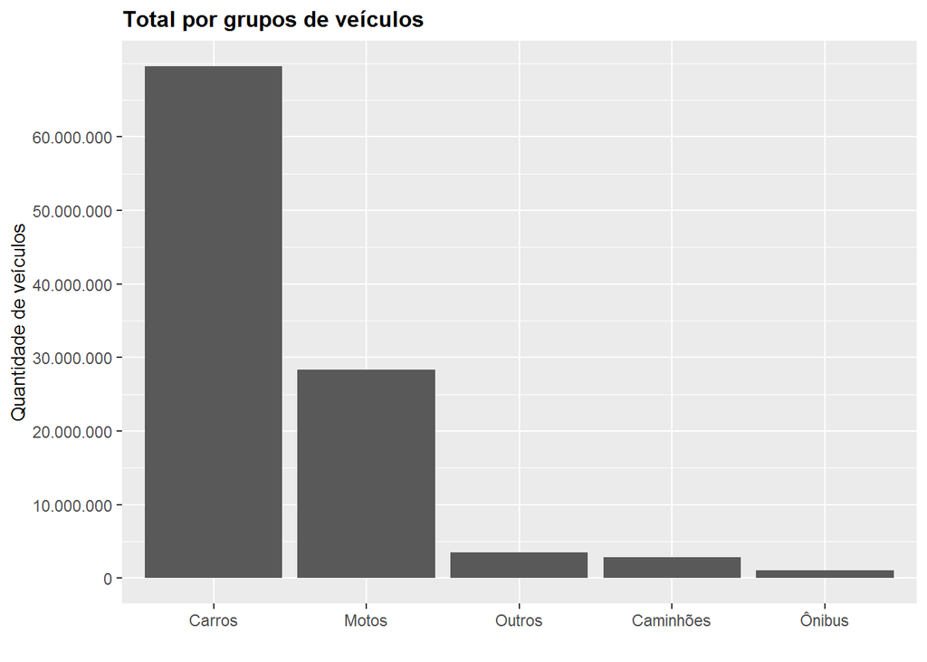

```r
max_tipo_frota_grupo <- max(df_frotas_grupos$total)

ggplot(df_frotas_grupos, aes(x= reorder(grupo, -total), y=total)) +
  geom_bar(stat = "identity") +
  ggtitle('Total por grupos de veículos') +
  xlab('') +
  ylab('Quantidade de veículos') +
  scale_y_continuous(labels = point, limits = c(0,max_tipo_frota_grupo), breaks = seq(0, max_tipo_frota_grupo, by=10000000)) +
  theme(legend.position="none",
        plot.title = element_text(size = 12, face='bold'),
        axis.title = element_text(size=10, color='black'))
```

Com o agrupamento de veículos, a diferença do grupo carros para os demais é ainda maior, com este ficando com 66% da quantidade da frota total de veículos, seguida das motos com um pouco mais de 1/4 do total nacional, e as demais categorias somam cerca de 7%.

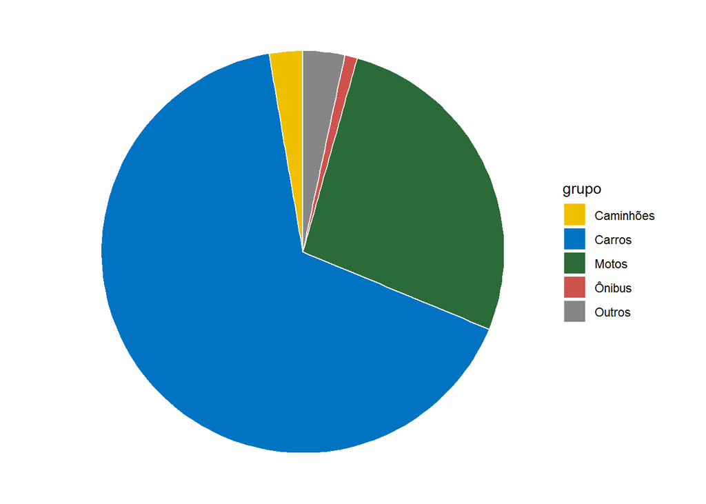

```r
cores <- c("#EFC000", "#0073C2", "#2b6a39", "#CD534C", "#868686")

ggplot(df_frotas_grupos, aes(x="", y=total, fill=grupo))+
  geom_bar(stat="identity", width = 1, color="white")+
  coord_polar("y", start=0) +
  scale_fill_manual(values = cores) +
  theme_void()
```

### Análise: Regiões e Estados

Agora que sabemos quantos veículos e quais seus tipos são os preferidos dos brasileiros, podemos descer um nível na análise, e entender a distribuição da frota de veículos nas regiões e nos estados.

**5. Mostrar uma tabela com as frotas por região.**

```r
sql_r <- "SELECT nome_regiao, SUM(total_frota) as Total FROM df_frotas GROUP BY nome_regiao"
df_frotas_regiao_total <- sqldf(sql_r)
df_frotas_regiao_total$frota_rel <- round((df_frotas_regiao_total$Total / frota_total) * 100, 4)
df_frotas_regiao_total <- df_frotas_regiao_total %>% arrange(desc(df_frotas_regiao_total$Total))

kable(df_frotas_regiao_total, caption = 'Veículos por região')
```

Veículos por região

| nome_regiao | Total | frota_rel |
| --- | --- | --- |
| Sudeste | 51009181 | 48.4067 |
| Sul | 20647724 | 19.5943 |
| Nordeste | 18288563 | 17.3555 |
| Centro-Oeste | 10591660 | 10.0513 |
| Norte | 4839224 | 4.5923 |

```r
sql <- "SELECT nome_estado, uf, SUM(total_frota) as Total, nome_regiao FROM df_frotas GROUP BY nome_estado, nome_regiao"
df_frotas_estados_total <- sqldf(sql)
df_frotas_estados_total$frota_rel <- round((df_frotas_estados_total$Total / frota_total) * 100, 4)
```

**6. Plotar gráfico com a distribuição da frota de veículos total, por estado. E se possível, destacando suas regiões**

```r
df_frotas_estados_total %>%
    arrange(desc(Total)) %>%
    hchart(type="bar", hcaes(x= nome_estado, y=Total, group=nome_regiao)) %>%
    # hchart(type="treemap", hcaes(x= tipo, value=total, color=total))
    hc_title(text = 'Total de veículos por estado') %>%
    hc_subtitle(text = "Fonte: Denatran (março/2020)") %>%
    hc_yAxis(title = list(enabled = FALSE, labels = list(format ="{value: %b}"), style = list(color = '#333333', fontFamily = "Arial"))) %>%
    hc_xAxis(title = list(text = "Estados"), style = list(color = '#333333', fontFamily = "Arial")) %>%
    hc_add_theme(hc_theme_flat()) %>%
    hc_size(NULL, 600)
```

[interactive chart not shown]

Com este gráfico e a tabela podemos ver que:

- a maior parte da frota está concentrada na região Sudeste, com quase a metade da frota do país (48%) e São Paulo sendo o estado com a maior delas, seguido por Minas Gerais;
- O Sul vem em seguida com 19,5%, com o Paraná, que tem a terceira maior frota do país, seguido pelo Rio Grande do Sul;
- No Nordeste (17,3%), a Bahia é o estado com a maior frota, seguido por Ceará e Pernambuco;
- No Centro Oeste (10%), o estado de Goiás é que possui a maior frota;
- A região Norte é a que possui a menor frota (4,5%), com os três estados de menor frota do país: Amapá, Roraima e Acre.

**7. Analisar as frotas de automóveis e cruzar com os dados da população.**

Se voltarmos no nosso primeiro gráfico desse documento, vamos ver que o tipo de veículo com mais unidades são os automóveis. Então, vamos repetir o gráfico anterior, mas dessa vez plotando apenas a frota de automóveis por estados.

```r
sql <- "SELECT id_estado, nome_estado, uf, nome_regiao, SUM(automovel) as Total FROM df_frotas GROUP BY id_estado, nome_estado, nome_regiao"
df_frotas_estados_automovel <- sqldf(sql)
df_frotas_estados_automovel$frota_rel <- round((df_frotas_estados_automovel$Total / frota_total) * 100, 4)
```

```r
df_frotas_estados_automovel %>%
    arrange(desc(Total)) %>%
    hchart(type="treemap", hcaes(x= nome_estado, value=Total, color=Total)) %>%
    hc_title(text = 'Total de automóveis por estado') %>%
    hc_subtitle(text = "Fonte: Denatran (março/2020)") %>%
    hc_yAxis(title = list(enabled = FALSE, labels = list(format ="{value: %b}"), style = list(color = '#333333', fontFamily = "Arial"))) %>%
    hc_xAxis(title = list(text = "Estados"), style = list(color = '#333333', fontFamily = "Arial")) %>%
    hc_add_theme(hc_theme_sandsignika()) %>%
    hc_size(NULL, 600)
```

[interactive chart not shown]

Observando nosso gráfico de árvore ou `treemap`, percebemos que as coisas não mudam muito, São Paulo continua bem a frente também na quantidade de automóveis, seguido por Minas Gerais, Rio de Janeiro, Paraná e Rio Grande do Sul.

Aproveitando o ensejo, entre os dados que estamos carregando, temos o da população por estado. Poderíamos cruzar estes dados, e apenas por curiosidade, verificar como seria a distribuição de carros por habitante dentro dos estados.

```r
sql <- "SELECT f.*, p.populacao_estimada_2019
        FROM df_frotas_estados_automovel f
        LEFT JOIN df_populacao p ON f.id_estado = p.id"
df_frotas_estados_auto_pop <- sqldf(sql)
df_frotas_estados_auto_pop$auto_pop <- round(df_frotas_estados_auto_pop$Total / df_frotas_estados_auto_pop$populacao_estimada_2019, 3)
df_frotas_estados_auto_pop$pop_auto <- round(df_frotas_estados_auto_pop$populacao_estimada_2019 / df_frotas_estados_auto_pop$Total, 3)
```

```r
hc_data <- df_frotas_estados_auto_pop %>% arrange(-pop_auto, -auto_pop)
hchart(hc_data, type="treemap", hcaes(x= nome_estado, value=pop_auto, color=auto_pop)) %>%
# hchart(type="treemap", hcaes(x= tipo, value=total, color=total))
hc_title(text = 'Quantidade de habitantes por automóveis por estado') %>%
hc_add_theme(hc_theme_google()) %>%
hc_size(NULL, 600)
```

[interactive chart not shown]

O título pode soar estranho e esse gráfico pode parecer confuso numa primeira olhada _ e eu sei que estou violando regras da visualização de dados, de tornar o gráfico o mais auto-explicativo possível _ mas é que aqui temos duas informações inversas, e queria mostrá-las dessa forma.

As cores mostram uma tendência, **quanto mais escuro, mais o estado tem veículos por habitante** (população estimada de 2019), então no caso, o estado que é o primeiro é o Distrito Federal, seguido por Santa Catarina, São Paulo e Paraná; Maranhão é o último e o Pará o penúltimo.

Os estados com os **quadros maiores** são o inverso, ou seja, os que **têm menos carros por habitante**. Mas ao colocar o mouse no gráfico, é possível ver a informação, por exemplo, no Maranhão, `a cada 15 pessoas, temos um automóvel`, enquanto que no Distrito Federal `a cada 2 pessoas, temos um automóvel`.

**8. Plotar gráfico com a distribuição da frota por tipo de veículos nos estados.**

Para analisar as frotas por estados, temos a dificuldade de termos 27 deles e apresentar a todos. Portanto teremos que dar um jeito de passar o valor do estado que queremos analisar (no caso apenas a UF), e retornar seus dados. Para esta análise, vamos apenas mostrar o estado de São Paulo.

Antes de tudo vamos criar um novo dataframe, agrupando os dados.

```r
#df_frotas[, 3:28]
#names(df_frotas)

df_frotas_estados <- sqldf("SELECT
                            nome_estado,
                            uf,
                            SUM(automovel) as Automovel,
                            SUM(bonde) as Bonde,
                            SUM(caminhao) as Caminhao,
                            SUM(caminhao_trator) as 'Caminhao trator',
                            SUM(caminhonete) as Caminhonete,
                            SUM(camioneta) as Camioneta,
                            SUM(chassi_plataforma) as 'Chassi plataforma',
                            SUM(ciclomotor) as Ciclomotor,
                            SUM(micro_onibus) as 'Micro-onibus',
                            SUM(motocicleta) as Motocicleta,
                            SUM(motoneta) as Motoneta,
                            SUM(onibus) as Onibus,
                            SUM(quadriciclo) as Quadriciclo,
                            SUM(reboque) as Reboque,
                            SUM(semirreboque) as Semirreboque,
                            SUM(side_car) as 'Side car',
                            SUM(outros) as Outros,
                            SUM(trator_de_esteiras) as 'Trator de esteiras',
                            SUM(trator_de_rodas) as 'Trator de rodas',
                            SUM(triciclo) as Triciclo,
                            SUM(utilitario) as Utilitario
                           FROM df_frotas
                           GROUP BY nome_estado")
```

```r
# Essa função recebe o dataframe com os estados, a uf do estado que queremos analisar
# e retorna uma linha com os dados que serão usados no gráfico
dataframeEstado <- function(df, uf = 'SP'){
  n_cols <- dim(df)[2]
  t_df <- as.data.frame(t(df[df$uf == uf,3:n_cols]))

  if(is.data.frame(t_df) & ncol(t_df) == 0){
    empty_df <- data.frame(Ints=integer())
    return(empty_df)
  }

  colnames(t_df)[1] <- 'total' # renomear coluna
  t_df$total <- sapply(t_df$total, as.numeric) # converte os valores em formato numérico
  t_df <- cbind(tipo = rownames(t_df), t_df) # criar coluna com os tipos
  rownames(t_df) <- NULL # zerar índice
  t_df <- t_df[t_df$total > 0,] # não retornar valores zerados
  return(t_df)
}

# Recebe a UF e retorna o nome do estado
nomeEstado <- function(uf = ''){
  if(!is.null(uf)){
    sql <- sprintf('SELECT nome_estado FROM df_cidades WHERE uf = "%s" LIMIT 1', uf)
    estado_nome <- sqldf(sql)
    return(estado_nome)
  } else {
    return("")
  }
}

# Função para gerar o gráfico
graficoEstado <- function(df, uf = 'SP'){

  df_estado <- dataframeEstado(df, uf) # trazer o dataframe apenas com os dados que serão plotados

  # Verifica se o dataframe possui dados
  if(is.data.frame(df_estado) & nrow(df_estado) == 0){
    return("Erro: Nenhum dado encontrado.")
  }

  estado_nome <- nomeEstado(uf) # Setar o nome do estado

  df_estado %>%
    arrange(desc(total)) %>%
    hchart(type="bar", hcaes(x= tipo, y=total)) %>%
    hc_title(text = paste('Total por tipo de veículos por estado:', estado_nome)) %>%
    hc_subtitle(text = "Fonte: Denatran (março/2020)") %>%
    hc_yAxis(title = list(enabled = FALSE, labels = list(format ="{value: %b}"), style = list(color = '#333333', fontFamily = "Arial"))) %>%
    hc_xAxis(title = list(text = "Tipos de veículos"), style = list(color = '#333333', fontFamily = "Arial")) %>%
    hc_add_theme(hc_theme_google())
}


graficoEstado(df_frotas_estados, 'SP')
```

[interactive chart not shown]

Para encerrarmos nossa análise, temos a quantidade de veículos por tipo no estado de São Paulo. Mais de 18 milhões de automóveis, seguida por motocicleta, caminhonete, camioneta, motoneta e caminhão. Devido as diferenças de proporção dos valores das barras, os veículos com menos de 100.000 unidades podem não aparecer no gráfico, apenas seus nomes _ apenas os que tinham valor zero foram dispensados.